# Graphics

Xu Liu

# 1 An overview of R graphics

A well-crafted graph can help you make meaningful comparisons among thousands of pieces of information, extracting patterns not easily found through other methods. This is one area where R shines.

R includes different packages for plotting data. Two packages build directly on top of the graphics engine: the **graphics** package and the **grid** package. These represent two largely incompatible graphics systems and they divide the bulk of graphics functionality in R into two separate worlds.

The `graphics` package contains a wide variety of functions for plotting data. This chapter gives an overview of the graphics package. We’ll discuss **grid** packages, especially `lattice` and `ggplot2`, in Chapter 7.

In this chapter,

- We first review general methods for working with graphs.
  - How to create and save graphs.
  - How to modify the features that are found in any graph.
- Then, we’ll focus on specific types of graphs, including
  - **Scatter Plots**
  - **Time Series**
  - **Bar Charts**
  - Other Plots
- Finally, we’ll investigate ways to combine multiple graphs into one overall graph.

# 2 Working with graphics

## 2.1 Create and save graphs

- Consider the following five lines:

```r
attach(mtcars)
plot(wt, mpg)
abline(lm(mpg~wt))
title("Regression of MPG on Weight")
detach(mtcars)
```

- First we **attach** the data frame `mtcars`. Then we open a graphics window and **generates** a scatter plot between automobile weight on the horizontal axis and miles per gallon on the vertical axis. We use the third statement to **add a line** of best fit and the fourth statement to **add a title**. Finally, we **detaches** the data frame.
- In R, graphs are typically created in this interactive fashion.

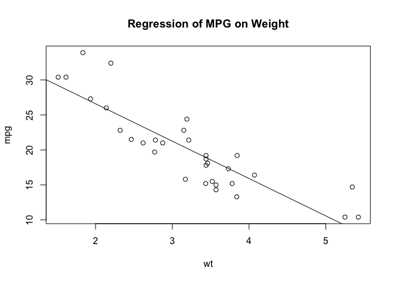

- You can save your graphs via code or through GUI menus.
- Using code
  - To save a graph via code, **sandwich** the statements that produce the graph between a statement that sets a destination and a statement that closes that destination.

  ```r
  pdf("mygraph.pdf")
   attach(mtcars)
   plot(wt, mpg)
   abline(lm(mpg~wt))
   title("Regression of MPG on Weight")
   detach(mtcars)
  dev.off()
  ```

  - In addition to `pdf()`, you can use the functions `win.metafile()`, `png()`, `jpeg()`, `bmp()`, `tiff()`, `xfig()`, and `postscript()` to save graphs in other formats. See chapter 1, section 7.2 for more details on sending graphic output to files.
- Via GUI

  We discuss the methods in RStudio.
  - On a Mac and window platform, select **Export > Save as…** from the plots window, and choose the format and location desired in the resulting dialog.
  - If you just want to copy the image, click **Zoom**, **right-clicking** on the plot zoom window, and select **copy image**, then you can paste it into an appropriate file type, such as a *Word* document.

## 2.2 Using graphical parameters

- Let’s start with a simple example. The following dataset describes patient response to two drugs at five dosage levels.

**Table 6.1**

| Dosage | Response to Drug A | Response to Drug B |
| --- | --- | --- |
| 20 | 16 | 15 |
| 30 | 20 | 18 |
| 40 | 27 | 25 |
| 45 | 40 | 31 |
| 60 | 60 | 40 |

- This data can be input from keyboard.

```r
dose  <- c(20, 30, 40, 45, 60)
drugA <- c(16, 20, 27, 40, 60)
drugB <- c(15, 18, 25, 31, 40)
```

- A simple line graph relating dose to response for drug A can be created by using

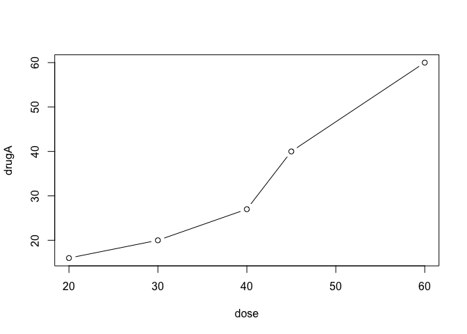

```r
# Figure 2
plot(dose, drugA, type="b")
```

**Plot()** is a generic function, which can draw many types of objects, including **vectors**, **tables**, and **time series**. In this case, `plot(x, y, type="b")` places x on the horizontal axis and y on the vertical axis, plots the (x, y) data points, and connects them with line segments. The option `type="b"` indicates that both points and lines should be plotted.

**Graphical parameters** can be used to specify fonts, colors, line styles, axes, reference lines, and annotations. These values are specified for the settings either with a call to the `par()` function or as arguments to a specified graphics function such as `plot()`.

- **Note**: The methods discussed here will work on all the graphs described in the class, with the **exception** of those created with the `lattice` package and `ggplot2` package in next chapter. (These two packages have their own methods for customizing a graph’s appearance.)

### 2.2.1 Adding arguments to plot()

- One way to specify graphical parameters is by providing the `optionname=value` pairs directly to a high-level plotting function.
  - (Not all high-level plotting functions allow you to specify all possible graphical parameters, but we’ll introduce this method first.)

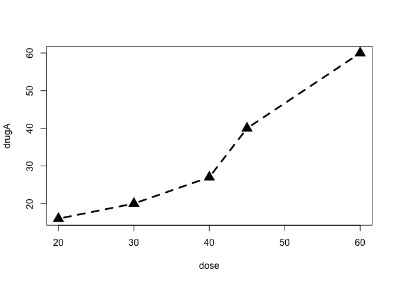

  ```r
  # Figure 3
  plot(dose, drugA, type="b", lty=2, pch=17, lwd=3, cex=2)
  ```

  - This statement changes the line type to dashed(`lty=2`) and symbol for points to a solid triangle(`pch=17`)(rather than a solid line and an open circle by default, as you can see from Figure 2)
  - `lwd=3` means the line is three times wider than the default width and `cex=2` means the plotting symbols are twice as large as the default size.
- Check parameters for symbols and lines in Table 6.2

Table 6.2

| Parameter | Description |
| --- | --- |
| type | Specifies what type of plot should be drawn(see Figure 6.4). |
| pch | Specifies the symbol to use when plotting points (see Figure 6.5). |
| cex | Specifies the symbol size. cex is a number indicating the amount by which plotting symbols should be scaled relative to the default. 1=default, 1.5 is 50% larger, 0.5 is 50% smaller, and so forth. |
| lty | Specifies the line type (see Figure 6.5). |
| lwd | Specifies the line width. `lwd` is expressed relative to the default (default=1). For example, `lwd=2` generates a line twice as wide as the default. |

Figure 6.4

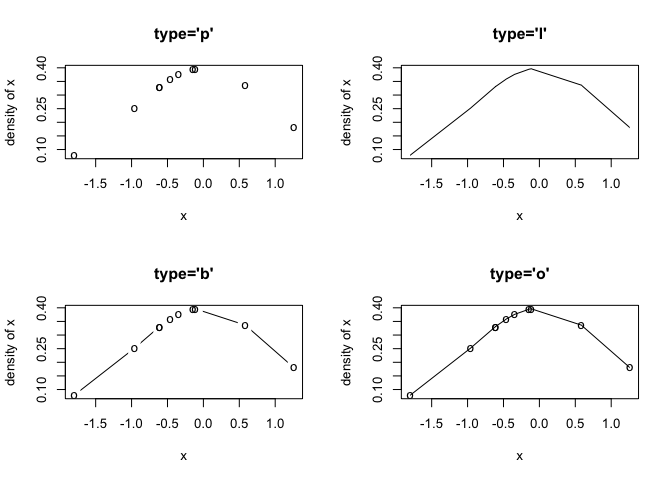

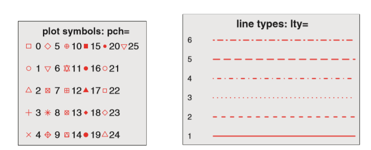

Figure 6.5

- To change colors, use the following parameters.

Table 6.3

[output not shown]

- To specify text size, font and style

Table 6.4

| Parameter | Description\| |
| --- | --- |
| cex | Number indicating the amount by which plotted text should be scaled relative to the default. 1=default, 1.5 is 50% larger, 0.5 is 50% smaller, etc. |
| cex.axis | Magnification of axis text relative to `cex`. |
| cex.lab | Magnification of axis labels relative to `cex`. |
| cex.main | Magnification of titles relative to `cex`. |
| cex.sub | Magnification of subtitles relative to `cex`. |

Table 6.5

| Parameter | Description |
| --- | --- |
| font | Integer specifying font to use for plotted text.. 1=plain, 2=bold, 3=italic, 4=bold italic, 5=symbol (in Adobe symbol encoding). |
| font.axis | Font for axis text. |
| font.lab | Font for axis labels. |
| font.main | Font for titles. |
| font.sub | Font for subtitles. |
| ps | Font point size (roughly 1/72 inch). The text size = ps*cex. |
| family | Font family for drawing text. Standard values are serif, sans, and mono. |

- To control the plot dimensions and margin sizes

Table 6.6

| Parameter | Description |
| --- | --- |
| pin | Plot dimensions (width, height) in inches. |
| mai | Numerical vector indicating margin size where `c(bottom, left, top, right)` is expressed in inches. |
| mar | Numerical vector indicating margin size where `c(bottom, left, top, right)` is expressed in lines. The default is `c(5, 4, 4, 2) + 0.1`. |

- The code `par(pin=c(4,3), mai=c(1,.5, 1, .2))` produces graphs that are 4 inches wide by 3 inches tall, with a 1-inch margin on the bottom and top, a 0.5-inch margin on the left, and a 0.2-inch margin on the right.
  - To include axis and text options.

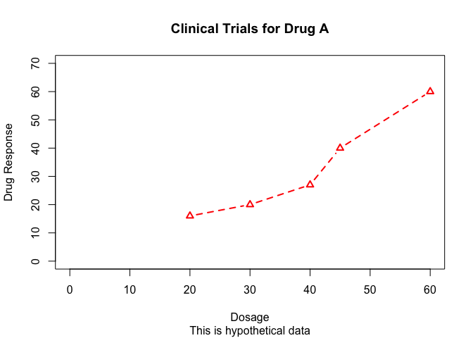

  ```r
  # Figure 4
  plot(dose, drugA, type="b",
       col="red", lty=2, pch=2, lwd=2,
       main="Clinical Trials for Drug A",
       sub="This is hypothetical data",
       xlab="Dosage", ylab="Drug Response",
       xlim=c(0, 60), ylim=c(0, 70))
  ```

### 2.2.2 Using low-level graphics functions

However, not all functions allow you to add these options. See the help for the function of interest to see what options are accepted. In this case, possible options are to add further output to the plot using **low-level** graphics functions.

- Note: Some high-level plotting functions include default titles and labels. They can be removed by adding ann=FALSE in the `plot()` statement or in a separate `par()` statement(which we’ll discuss later).
- Titles

```r
title(main="main title", sub="sub-title", xlab="x-axis label", ylab="y-axis label")
```

```r
title(main="My Title", col.main="red",
      sub="My Sub-title", col.sub="blue",
      xlab="My X label", ylab="My Y label",
      col.lab="green", cex.lab=0.75)
```

- Axes

```r
axis(side, at=, labels=, pos=, lty=, col=, las=, tck=, ...)
```

| Parameter | Description |
| --- | --- |
| side | An integer indicating the side of the graph to draw the axis (1=bottom, 2=left, 3=top, 4=right). |
| at | A numeric vector indicating where tick marks should be drawn.\| |
| labels | A character vector of labels to be placed at the tick marks (if NULL, the at values will be used). |
| pos | The coordinate at which the axis line is to be drawn (that is, the value on the other axis where |
|  | it crosses). |
| lty | Line type. |
| col | The line and tick mark color. |
| las | Labels are parallel (=0) or perpendicular (=2) to the axis. |
| tck | Length of tick mark as a fraction of the plotting region (a negative number is outside the graph, |
|  | a positive number is inside, 0 suppresses ticks, 1 creates gridlines); the default is 0.01. |
| (…) | Other graphical parameters. |

- Reference lines

  ```r
  abline(h=yvalues, v=xvalues)
  ```

- Legend

  ```r
  legend(location, title, legend, ...)
  ```

- Example

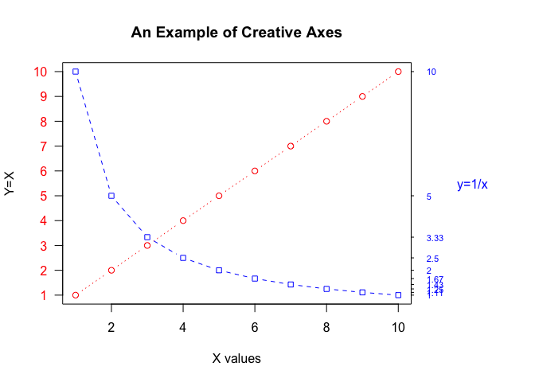

  ```r
  # Figure 5
  #Specify data
  x <- c(1:10)
  y <- x
  z <- 10/x

  opar <- par(no.readonly=TRUE)

  #Increase margins
  par(mar=c(5, 4, 4, 8) + 0.1)

  #Plot x versus y
  plot(x, y, type="b",
   pch=21, col="red",
   yaxt="n", lty=3, ann=FALSE)

  #Add x versus 1/x line
  lines(x, z, type="b", pch=22, col="blue", lty=2)

  #Draw your axes
  axis(2, at=x, labels=x, col.axis="red", las=2)

  axis(4, at=z, labels=round(z, digits=2),
   col.axis="blue", las=2, cex.axis=0.7, tck=-.01)

  #Add titles and text
  mtext("y=1/x", side=4, line=3, cex.lab=1, las=2, col="blue")

  title("An Example of Creative Axes",
    xlab="X values",
    ylab="Y=X")

  par(opar)
  ```

### 2.2.3 Function `par()`

- By adding parameters to `plot()`, these options are only in effect for that specific graph.
- In this case, to plot two graghs with the same parameters we have to type:

```r
plot(dose, drugA, type="b", lty=2, pch=17,lwd=3, cex=2, col="red")
plot(dose, drugB, type="b", lty=2, pch=17,lwd=3, cex=2, col="blue")
```

- Typing the same parameters several time makes the code tedious and error prone. Besides, as we mentioned before, not all plotting functions allow you to specify all possible graphical parameters in this way. Alternatively, we can use **par()** function.
- The **par()** function sets values that will be in effect for the rest of the session or until they’re changed. The format is `par(optionname=value, optionname=value, ...)`. Adding the `no.readonly=TRUE` option produces a list of current graphical settings that can be modified.
- Continuing our example, we write the code with `par()`

```r
# Figure 7
opar <- par(no.readonly=TRUE)
par(lty=2, pch=17,lwd=3, cex=2)
plot(dose, drugA, type="b", col="red")
plot(dose, drugB, type="b", col="blue")
par(opar)
```

- The first statement makes a **copy** of the current settings. The second statement **changes** the default parameters. We then **generate** the plot and **restore** the original settings.

[figure not shown]

# 3 Specific Types of Graphs

## 3.1 Scatter Plots

- From this section, we’ll introduce some specific types of graphs in **graphics** package.
- To show how to use **scatter plots**, we will look at cases of cancer in 2008 and toxic waste releases by state in 2006. Data on new cancer cases (and deaths from cancer) are tabulated by the American Cancer Society; information on toxic chemicals released into the environment is tabulated by the U.S. Environmental Protection Agency (EPA).
- The sample data is included in the `nutshell` package:

```r
# If you didn't install the nutshell packages, first type
# install.packages("nutshell")
library(nutshell)
data(toxins.and.cancer)
```

- To show a scatter plot, we can also use the `plot()` function. Let’s compare the overall cancer rate (number of cancer deaths divided by state population) to the presence of toxins (total toxic chemicals release divided by state area):

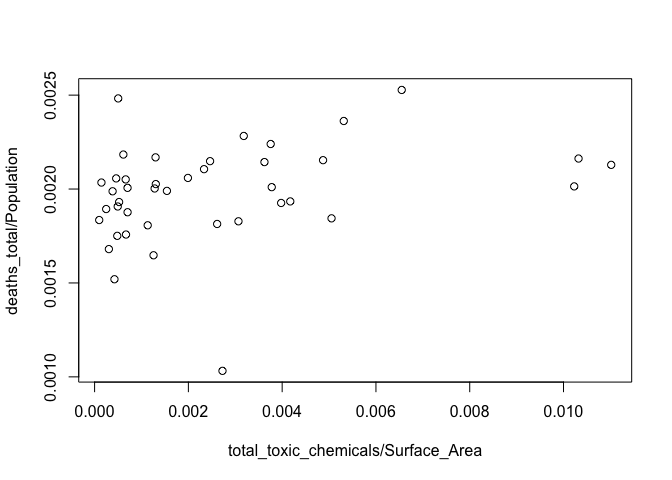

```r
# Figure 8
attach(toxins.and.cancer)
plot(total_toxic_chemicals/Surface_Area,deaths_total/Population)
```

- Suppose that you wanted to know which states were associated with which points. R provides some interactive tools for identifying points on plots.
  - We can use the `locator` function to tell us the coordinates of a specific point (or set of points). To do this, first plot the data. Next, type `locator(1)`. Then click on a point in the open graphics window. You would see results like this:

    ```r
    locator(1)
    ```

    $x

    [1] 0.0005163023

    $y

    [1] 0.002481683
  - Another useful function for identifying points is `identify()`. We pass in three arguments to `identify()`: the x-axis variable, the y-axis variable, and the variable whose values we would like to see printed for each point. Then clicking on a given point in the plot will cause R to print the value of the variable of interest. You can click **finish** to exit the function. The numbers printed under the `identify()` function correspond to the rows for the selected points.
  - To label all of the points at once, you could use the `text` function to add labels to the plot.

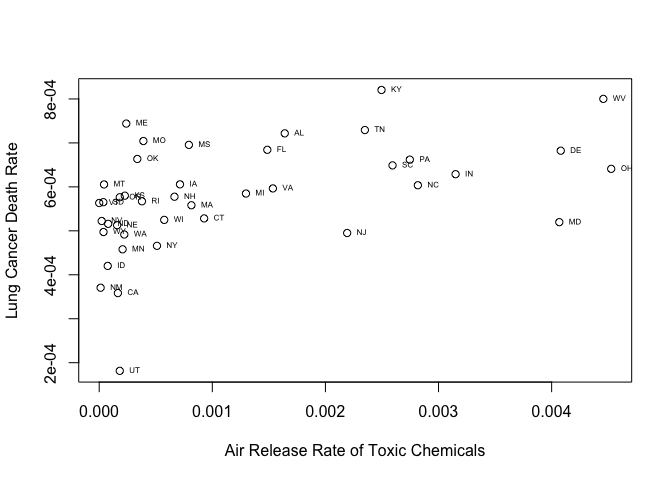

[output not shown]

    ```r
    # Figure 9
    plot(air_on_site/Surface_Area, deaths_lung/Population,
    xlab="Air Release Rate of Toxic Chemicals",
    ylab="Lung Cancer Death Rate")

    text(air_on_site/Surface_Area, deaths_lung/Population,
    labels=State_Abbrev,
    cex=0.5,
    pos=4)
    ```

- If you have a data frame with **n** different variables and you would like to generate a scatter plot for **each pair** of values in the data frame, try the `pairs` function. As an example, let’s plot the hits, runs, strikeouts, walks, and home runs for each Major League Baseball (MLB) player who had more than 100 at bats in 2008.

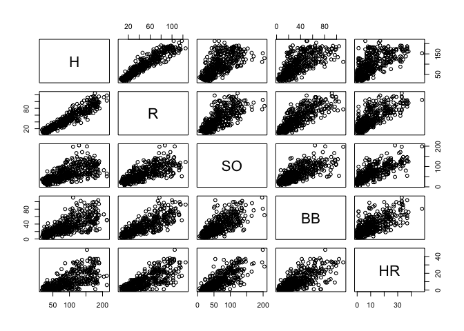

  ```r
  # Figure 10
  library(nutshell)
  data(batting.2008)
  pairs(batting.2008[batting.2008$AB>100, c("H","R","SO","BB","HR")])
  ```

## 3.2 Plotting Time Series

- R includes tools for plotting time series data. The plot function has a method for time series:

```r
plot(x, y = NULL, plot.type = c("multiple", "single"),
    xy.labels, xy.lines, panel = lines, nc, yax.flip = FALSE,
    mar.multi = c(0, 5.1, 0, if(yax.flip) 5.1 else 2.1),
    oma.multi = c(6, 0, 5, 0), axes = TRUE, ...)
```

- The arguments **x** and **y** specify **ts** objects, **panel** specifies how to plot the time series (by default, lines), and other arguments specify how to break time series into different plots (as in lattice). As an example, we’ll plot the turkey price data:

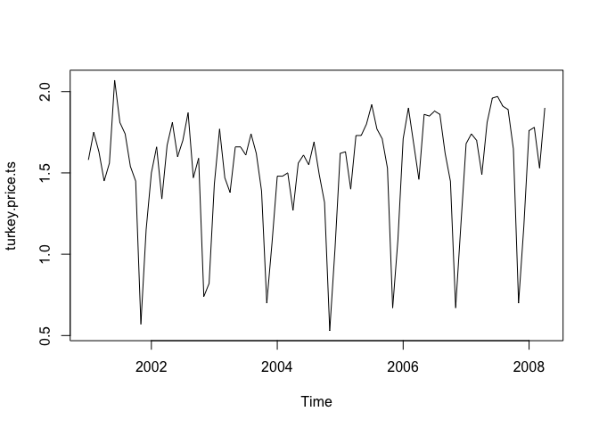

  ```r
  # figure 11
  library(nutshell)
  data(turkey.price.ts)
  plot(turkey.price.ts)
  ```

  As you can see, turkey prices are very seasonal. There are huge sales in November and December (for Thanksgiving and Christmas) and minor sales in spring (probably for Easter).
- Another way to look at seasonal effects is with an autocorrelation plot. You can also plot the autocorrelation function for a time series. The plot is generated by default when you call `acf`.

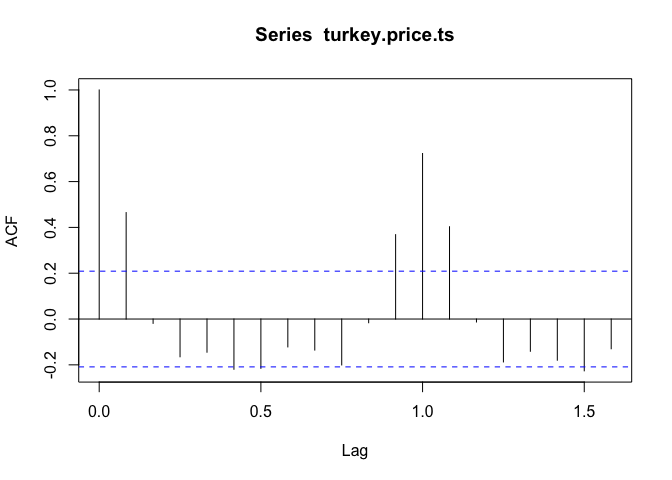

```r
# Figure 12
acf(turkey.price.ts)
```

- As you can see, points are correlated over 12-month cycles (and inversely correlated over 6-month cycles). Time series analysis is discussed further in Chapter 9.

## 3.3 Bar Charts

- To draw bar (or column) charts in R, use the `barplot` function.
- As an example, let’s look at doctoral degrees awarded in the United States between 2001 and 2006.

```r
library(nutshell)
data(doctorates)
```

- The barplot function can’t work with a data frame, so let’s first transform this into a matrix for plotting:

```r
# Figure 13
# make this into a matrix:
doctorates.m <- as.matrix(doctorates[2:7])
rownames(doctorates.m) <- doctorates[,1]
doctorates.m
```

```
##      engineering science education health humanities other
## 2001        5323   20643      6436   1591       5213  2159
## 2002        5511   20017      6349   1541       5178  2141
## 2003        5079   19529      6503   1654       5051  2209
## 2004        5280   20001      6643   1633       5020  2180
## 2005        5777   20498      6635   1720       5013  2480
## 2006        6425   21564      6226   1785       4949  2436
```

- Here we have used some statements discussed in the former chapters, check it if you feel confused.
- Let’s start by just showing a bar plot of doctorates in 2001 by type:

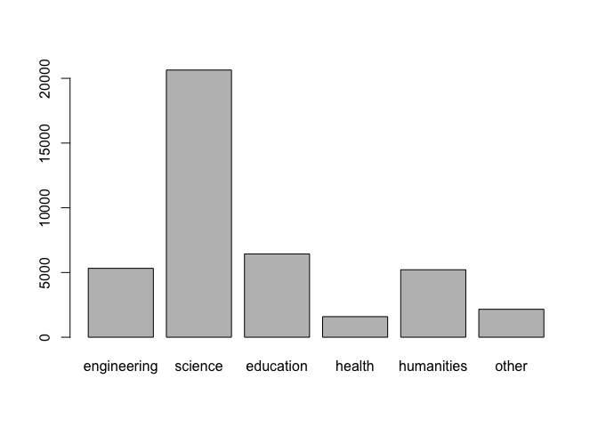

```r
# Figure 14
barplot(doctorates.m[1,])
```

- Suppose that we wanted to show all of the **different years** as bars stacked **next to** each other. Suppose that we also wanted the bars plotted **horizontally** and wanted to show a **legend** and different **colors** for the different years.

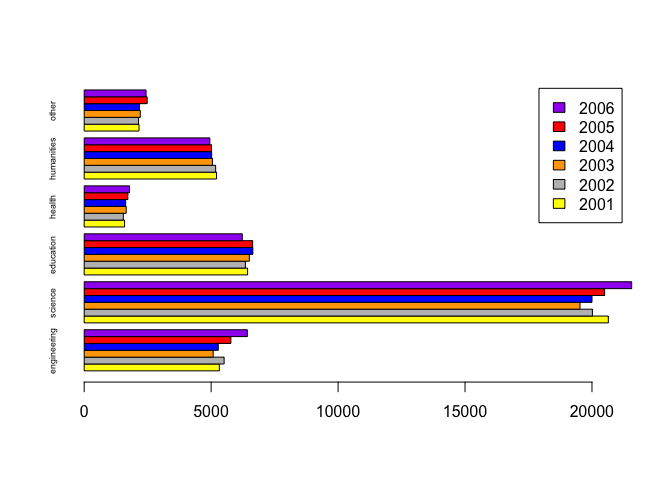

```r
# Figure 15
barplot(doctorates.m,beside=TRUE,horiz=TRUE,legend=TRUE,cex.names=.55,
        col=c("yellow","gray","orange","blue","red","purple"))
```

- Finally, suppose that we wanted to show doctorates by **year** as **stacked bars**. To do this, we need to **transform** the matrix so that each column is a year and each row is a discipline. We also need to make sure that there is enough room to see the legend, so we’ll extend the limits on the y-axis:

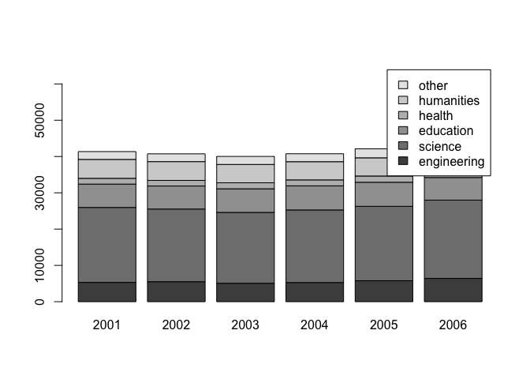

```r
# Figure 16
barplot(t(doctorates.m),legend=TRUE,ylim=c(0,66000))
```

- Though we haven’t introduced some arguments like `beside` `horiz` `col`, you can guess how they are used by comparing the two charts above.
- See `help` if you want more details about **barplot** parameters.

## 3.4 Other Plots

- Here we list some Other plots included in the `graphic` package.
- **boxplot()**

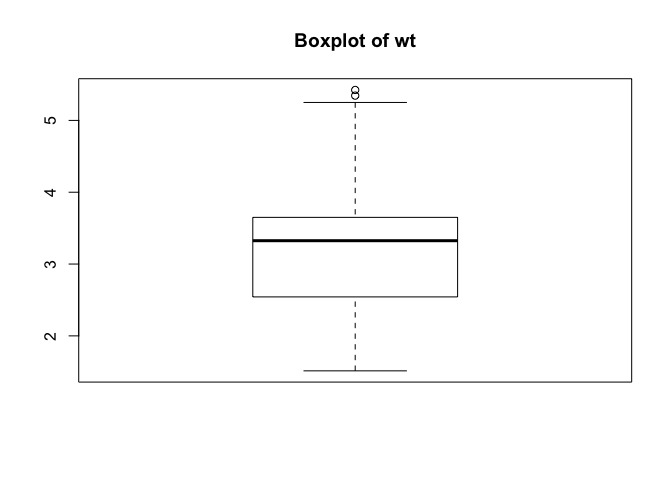

```r
# Figure 17
boxplot(mtcars$wt, main="Boxplot of wt")
```

- **pie()**

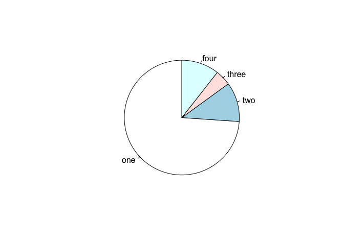

```r
# Figure 18
domestic.catch.2006 <-c(7752,1166,463,1108)
names(domestic.catch.2006) <-c("one","two","three","four")
pie(domestic.catch.2006,init.angle=90)
```

- **persp()**

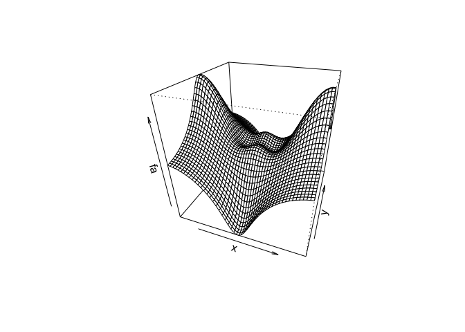

```r
# Figure 19
x=seq(-pi,pi,length =50)
y=x
f=outer(x,y,function (x,y)cos(y)/(1+x^2))
fa=(f-t(f))/2
persp(x,y,fa,theta=20,phi=30)
```

- **image()**

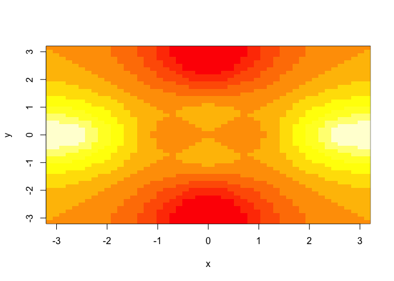

```r
# Figure 20
image(x,y,fa)
```

- **contour()**

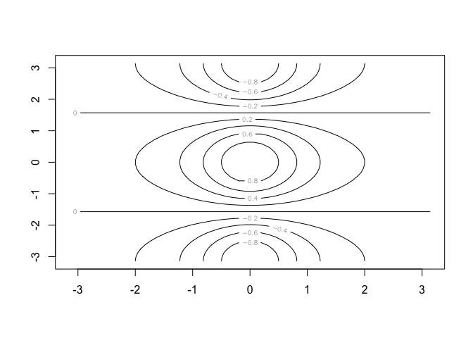

```r
# Figure 21
contour(x,y,f)
```

# 4 Combining Graphs

- R makes it easy to combine several graphs into one overall graph, using either the `par()` or `layout()` function.
- With the `par()` function, you can include the graphical parameter `mfrow=c(nrows, ncols)` to create a matrix of **nrows x ncols** plots that are filled in by row. Alternatively, you can use `mfcol=c(nrows, ncols)` to fill the matrix by columns.

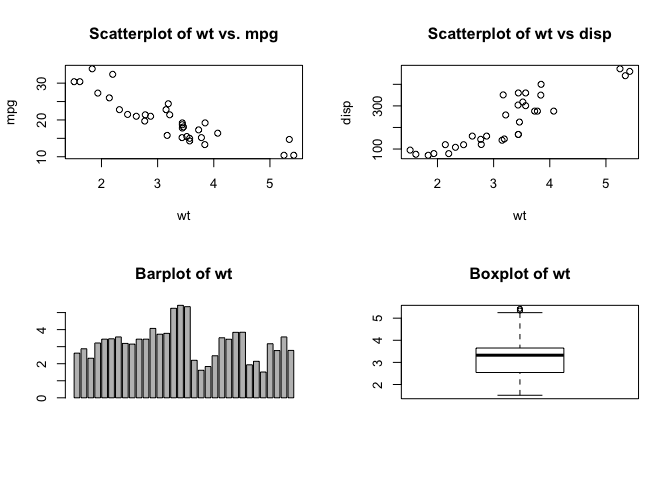

```r
# Figure 22
attach(mtcars)
opar <- par(no.readonly=TRUE)
par(mfrow=c(2,2))
plot(wt,mpg, main="Scatterplot of wt vs. mpg")
plot(wt,disp, main="Scatterplot of wt vs disp")
barplot(wt, main="Barplot of wt")
boxplot(wt, main="Boxplot of wt")
par(opar)
detach(mtcars)
```

- The `layout()` function has the form **layout(mat)** where **mat** is a matrix object specifying the location of the multiple plots to combine. In the following code, one figure is placed in row 1 and two figures are placed in row 2:

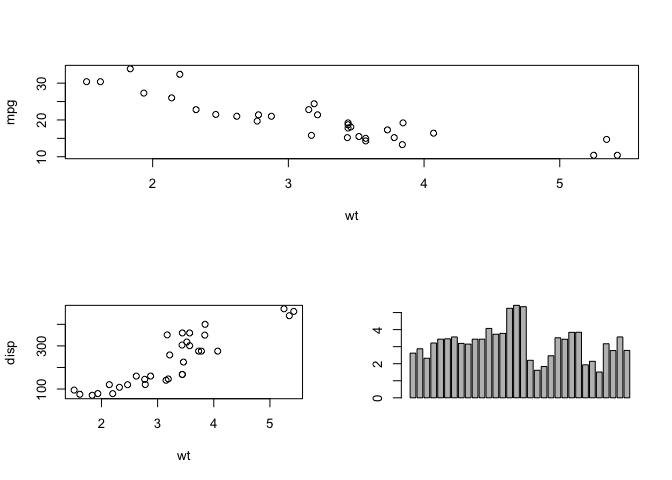

```r
# Figure 24
attach(mtcars)
layout(matrix(c(1,1,2,3), 2, 2, byrow = TRUE))
plot(wt,mpg)
plot(wt,disp)
barplot(wt)
detach(mtcars)
```

# 5 Exercises

- **Exercises 1**: Use the data of **Dose** and **DrugB** and add correct graphical parameters to your function to get the following graph. Then save the graph as pdf.

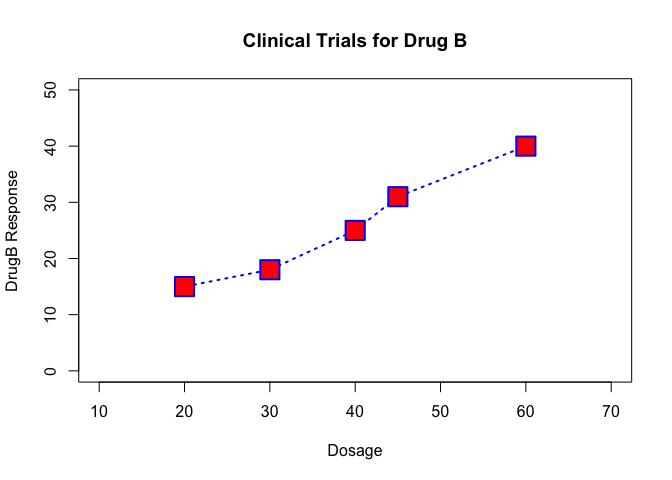

- **Exercise 2**: The `MASS` library contains the `Boston` data set, which records `medv` (median house value) for 506 neighborhoods around Boston. Draw a plot to find the relationship between `medv` and `lstat` (percent of households with low socioeconomic status). Find out the `age` (average age of houses) of the left lower point. (You can use `names` to see all the variables names in the dataset if you are interested.)

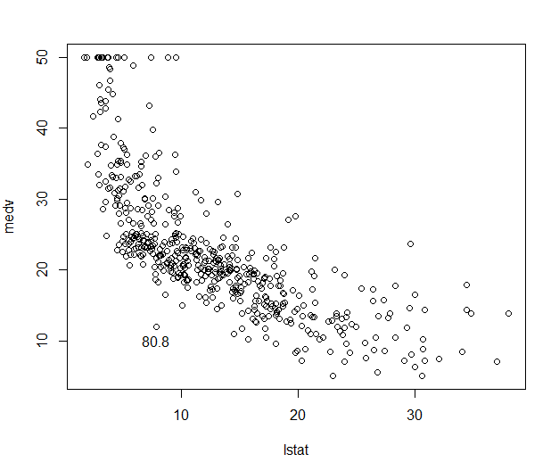

- **Exercise 3**: Use the data of **mtcars** and **drugs** , plot the following graph.(In the second graph, the red text are rownames of mtcars.)

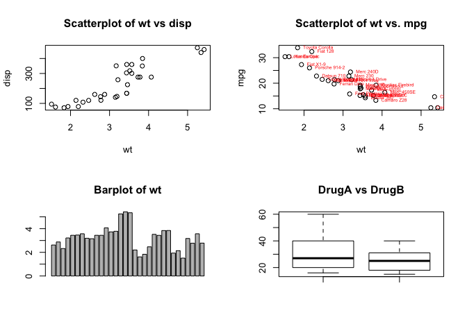

# 6 References

- Kabacoff, R. I. (2011). “*R in Action*”. Manning Publications Co.
- Adler, J. (2010). “*R in a nutshell: A desktop quick reference*”. O’Reilly Media, Inc.
- James, G., Witten, D., Hastie, T. and Tibshirani, R. (2013). *“An Introduction to Statistical Learning with Applications in R”*. Springer.
- Murrell, P. (2011). “*R Graphics*”. CRC Press.